# 1.10. NDVI Computation

### 1.10.1.1. Proceed to calculate NDVI for each semi-natural grasslands,extract the for grazed and non-grazed polygons

First we need to calculate the mean NDVI for the two periods (one for the early and another for the late season). This can be done by pkcomposite and/or pkstatprofile.

```python
# create the tif file on the vrt stack

!pkstatprofile -co  COMPRESS=LZW -nodata -3000 -f mean -f stdev  -i NDVI_first.vrt -o NDVI_first_mean_stdev.tif

!pkstatprofile -co  COMPRESS=LZW -nodata -3000 -f mean -f min -f max -i NDVI_first.vrt -o NDVI_first_mean_min_max.tif

!pkstatprofile -co  COMPRESS=LZW -nodata -3000 -f mean -f min -f max -i NDVI_second.vrt -o NDVI_second_mean_min_max.tif


#do it for the PR layer , right way to do it?

!pkstatprofile -co  COMPRESS=LZW -nodata 255 -f median -i PR_first.vrt -o PR_first_median.tif

!pkstatprofile -co  COMPRESS=LZW -nodata 255 -f median -i PR_second.vrt -o PR_second_median.tif


!pkstat -hist  -nbin  20 -src_min 0  -i     NDVI_first_mean_min_max.tif

!pkstat -hist  -nbin 20 -src_min 0  -i     PR_second_median.tif
```

[output not shown]

```
FileOpenError
```

In the next step, raster files need to be reprojected with gdal warp. All the others are in SWEREF99TM.+proj=utm +zone=33 +ellps=GRS80 +towgs84=0,0,0,0,0,0,0 +units=m +no_defs from https://spatialreference.org/ref/epsg/3006/

```python
#reproject to be able to extract the values from it with the help of shp file

!gdalwarp -t_srs "+proj=utm +zone=33 +ellps=GRS80 +towgs84=0,0,0,0,0,0,0 +units=m +no_defs" NDVI_first_mean_min_max.tif NDVI_reproj_first.tif

!gdalwarp -t_srs "+proj=utm +zone=33 +ellps=GRS80 +towgs84=0,0,0,0,0,0,0 +units=m +no_defs" NDVI_first_mean_min_max.tif NDVI_reproj_second.tif

!gdalwarp -t_srs "+proj=utm +zone=33 +ellps=GRS80 +towgs84=0,0,0,0,0,0,0 +units=m +no_defs" PR_first_median.tif PR_first_median_reproj_first.tif

!gdalwarp -t_srs "+proj=utm +zone=33 +ellps=GRS80 +towgs84=0,0,0,0,0,0,0 +units=m +no_defs" PR_second_median.tif PR_second_median_reproj_second.tif
```

Mask out the “bad” pixels from the two NDVI layers.

```bash
%%bash
#on the fly

pksetmask -co COMPRESS=DEFLATE -co ZLEVEL=9 \
-m PR_first_median_reproj_first.tif --operator='>' --msknodata 2 --nodata 0 --operator='>' --msknodata 3 --nodata 0 \
-i NDVI_reproj_first.tif -o NDVI_reproj_first.mm.tif


pksetmask -co COMPRESS=DEFLATE -co ZLEVEL=9 \
-m PR_second_median_reproj_second.tif --operator='>' --msknodata 2 --nodata 0 --operator='>' --msknodata 3 --nodata 0 \
-i NDVI_reproj_second.tif -o NDVI_reproj_second.mm.tif
```

Reclass these two NDVI tif with gdal.calc.

```python
!gdal_calc.py -A NDVI_reproj_first.mm.tif --type=Float32 --calc="A*0.0001" --outfile=NDVI_reproj_first.mm_reclass.tif

!gdal_calc.py -A NDVI_reproj_second.mm.tif --type=Float32 --calc="A*0.0001" --outfile=NDVI_reproj_second.mm_reclass.tif
```

Now this is done for whole Scandinavia, so potentially we can extract all grasslands in Sweden.

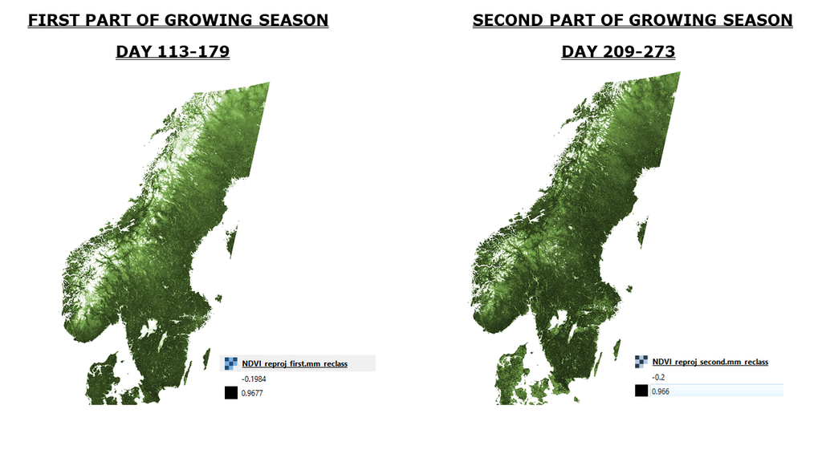

```bash
%%bash

#all grasslands with types
ogrinfo -al -geom=NO   TUVA/naturtyper/AoB_Naturtypsyta2016.shp | head -80
```

```
INFO: Open of `TUVA/naturtyper/AoB_Naturtypsyta2016.shp'
      using driver `ESRI Shapefile' successful.

Layer name: AoB_Naturtypsyta2016
Metadata:
  DBF_DATE_LAST_UPDATE=2017-06-20
Geometry: Polygon
Feature Count: 161005
Extent: (267574.436000, 6133616.710000) - (912473.370000, 7656870.384000)
Layer SRS WKT:
PROJCS["SWEREF99 TM",
    GEOGCS["SWEREF99",
        DATUM["SWEREF99",
            SPHEROID["GRS 1980",6378137,298.257222101,
                AUTHORITY["EPSG","7019"]],
            TOWGS84[0,0,0,0,0,0,0],
            AUTHORITY["EPSG","6619"]],
        PRIMEM["Greenwich",0,
            AUTHORITY["EPSG","8901"]],
        UNIT["degree",0.0174532925199433,
            AUTHORITY["EPSG","9122"]],
        AUTHORITY["EPSG","4619"]],
    PROJECTION["Transverse_Mercator"],
    PARAMETER["latitude_of_origin",0],
    PARAMETER["central_meridian",15],
    PARAMETER["scale_factor",0.9996],
    PARAMETER["false_easting",500000],
    PARAMETER["false_northing",0],
    UNIT["metre",1,
        AUTHORITY["EPSG","9001"]],
    AUTHORITY["EPSG","3006"]]
ID: Integer64 (10.0)
FALTID_ID: Integer64 (10.0)
NATURTYP1: String (30.0)
PROCENT1: Integer64 (10.0)
NATURTYP2: String (30.0)
PROCENT2: Integer64 (10.0)
NATURTYP3: String (30.0)
PROCENT3: Integer64 (10.0)
AREAL: Real (19.10)
```

[output cut: 25 more lines]

```
  OBJECTID (Real) = 0.0000000000

OGRFeature(AoB_Naturtypsyta2016):1
  ID (Integer64) = 3
  FALTID_ID (Integer64) = 51639
  NATURTYP1 (String) = 9070
  PROCENT1 (Integer64) = 100
  NATURTYP2 (String) = (null)
  PROCENT2 (Integer64) = 0
  NATURTYP3 (String) = (null)
  PROCENT3 (Integer64) = 0
  AREAL (Real) = 0.9984382118
  REGANSV (String) = eygra
  REGDAT (Date) = 2007/06/14
  NATURTYP (String) = 9070
```

For simplicity, we run first only run for the smaller part as we did before (i.e Södermanland).

```python
!pkextractogr -f CSV -srcnodata -3.4028234663852886e+38 -r mean -r stdev -r min  -i NDVI_reproj_first.mm_reclass.tif -s TUVA/Sodermanland/Sodermanland_grassland_v1.shp  -o  stat_NDVI_first.csv
!pkextractogr -f CSV -srcnodata -3.4028234663852886e+38 -r mean -r stdev -r min  -i NDVI_reproj_second.mm_reclass.tif -s TUVA/Sodermanland/Sodermanland_grassland_v1.shp -o  stat_NDVI_second.csv
```

After we get the csv-s with the ndvi values for each grassland type, now we can proceed and plot them. We will use R for this step.

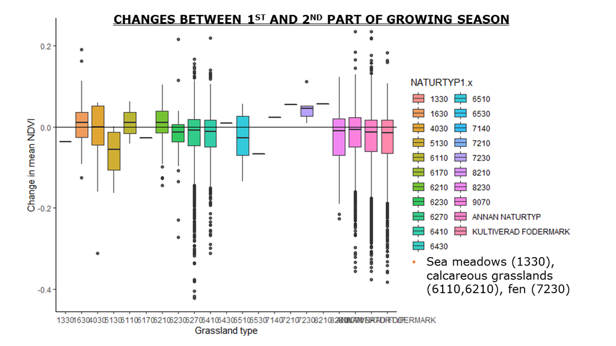

```python
R --vanilla -q

stat_NDVI_first <- read.csv("/SU/course/Geocomputation/LVM_shared/stat_NDVI_first.csv")
stat_NDVI_second <- read.csv("/SU/course/Geocomputation/LVM_shared/stat_NDVI_second.csv")

#plot one-by-one

ggplot(stat_NDVI_first, aes(x = NATURTYP1, y = X_mean, fill=NATURTYP1))+
  geom_boxplot(size=0.5, alpha=0.8)+
  labs(x= "Grassland type", y="mean NDVI") +
  theme_classic()


ggplot(stat_NDVI_second, aes(x = NATURTYP1, y = mean, fill=NATURTYP1))+
  geom_boxplot(size=0.5, alpha=0.8)+
  labs(x= "Grassland type", y="mean NDVI") +
  theme_classic()

 names (stat_NDVI_first)

 library (dplyr)

 first_ndvi <-stat_NDVI_first %>% select(-c(REGANSV,REGDAT,OBJECTID,URL,LnKod))%>%
  rename(mean_first=X_mean, std_first=X_stdev)

 second_ndvi <-stat_NDVI_second %>% select(-c(REGANSV,REGDAT,OBJECTID,URL,LnKod))%>%
   rename(mean_second=mean, std_second=stdev)

#combine the two with the unique ID

combined<-full_join(second_ndvi, first_ndvi, by="ID")

#calculate the changes in ndvi between the two parts

ndvi_shift<-combined_v1 %>%mutate(ndvi_change = mean_second -mean_first)

names(ndvi_shift)

ggplot(ndvi_shift, aes(x = NATURTYP1.x, y = ndvi_change, fill=NATURTYP1.x))+
  geom_boxplot(size=0.5, alpha=0.8)+
  labs(x= "Grassland type", y="Change in mean NDVI") +
  geom_hline(yintercept = 0)+
  theme_classic()
```

Look at the raster file with all the grazed areas in Sweden.Called: NMDS_bete layer with grazed areas -> tif -> value 6 is grazed. This dataset is based on “betesmark” grasslands from LPIS, Jordbruksverket.

```bash
%%bash

gdalinfo /media/sf_LVM_shared/TUVA/NMD_Tillaggsskikt_Markanvandning| head -80

TUVA/NMD_Tillaggsskikt_Markanvandning/NMD_markanv_bete_v1.tif

openev TUVA/NMD_Tillaggsskikt_Markanvandning/NMD_markanv_bete_v1.tif
```

```
Driver: GTiff/GeoTIFF
Files: TUVA/NMD_Tillaggsskikt_Markanvandning/NMD_markanv_bete_v1.tif
       TUVA/NMD_Tillaggsskikt_Markanvandning/NMD_markanv_bete_v1.aux
Size is 69000, 157000
Coordinate System is:
PROJCS["SWEREF99 TM",
    GEOGCS["SWEREF99",
        DATUM["SWEREF99",
            SPHEROID["GRS 1980",6378137,298.257222101,
                AUTHORITY["EPSG","7019"]],
            TOWGS84[0,0,0,0,0,0,0],
            AUTHORITY["EPSG","6619"]],
        PRIMEM["Greenwich",0,
            AUTHORITY["EPSG","8901"]],
        UNIT["degree",0.0174532925199433,
            AUTHORITY["EPSG","9122"]],
        AUTHORITY["EPSG","4619"]],
    PROJECTION["Transverse_Mercator"],
    PARAMETER["latitude_of_origin",0],
    PARAMETER["central_meridian",15],
    PARAMETER["scale_factor",0.9996],
    PARAMETER["false_easting",500000],
    PARAMETER["false_northing",0],
    UNIT["metre",1,
        AUTHORITY["EPSG","9001"]],
    AUTHORITY["EPSG","3006"]]
Origin = (240000.000000000000000,7680000.000000000000000)
Pixel Size = (10.000000000000000,-10.000000000000000)
Metadata:
  AREA_OR_POINT=Area
  TIFFTAG_RESOLUTIONUNIT=2 (pixels/inch)
  TIFFTAG_SOFTWARE=E
  TIFFTAG_XRESOLUTION=1
  TIFFTAG_YRESOLUTION=1
Image Structure Metadata:
  COMPRESSION=PACKBITS
  INTERLEAVE=BAND
Corner Coordinates:
Upper Left  (  240000.000, 7680000.000) (  8d27'25.81"E, 69d 6'19.35"N)
Lower Left  (  240000.000, 6110000.000) ( 10d55'38.56"E, 55d 4' 6.76"N)
```

[output cut: 25 more lines]

```
    0: 0,0,0,255
    1: 0,0,0,255
    2: 0,0,0,255
    3: 0,0,0,255
    4: 0,0,0,255
    5: 0,0,0,255
    6: 84,255,0,255
    7: 0,0,0,255
    8: 0,0,0,255
    9: 0,0,0,255
   10: 0,0,0,255
   11: 0,0,0,255
   12: 0,0,0,255
   13: 0,0,0,255
   14: 0,0,0,255
```

```
bash: line 2: openev: command not found
```

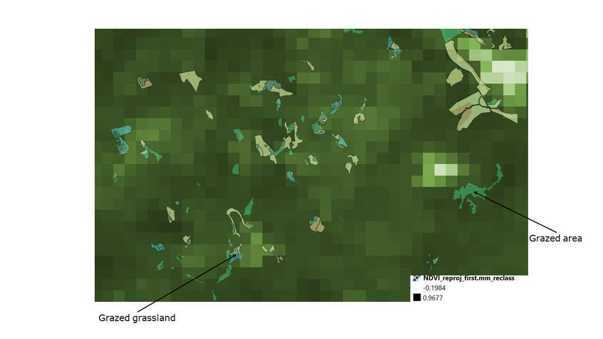

```python
!pkgetmask  -co COMPRESS=DEFLATE -co ZLEVEL=9 -min  5  -max  255 -data 1 -nodata 0 -ot Byte  -i  TUVA/NMD_Tillaggsskikt_Markanvandning/NMD_markanv_bete_v1.tif -o TUVA/NMD_Tillaggsskikt_Markanvandning/NMD_markanv_bete_v1_mask.tif
```

We can use polygon extraction to get the values for each grassland types and then later use the masked tif file for the grazed areas.

```python
#alternatively we can use this

!gdalwarp -ot Byte -of GTiff -tr 250.0 -250.0 -tap -cutline TUVA/Sodermanland/Sodermanland_grassland_v1.shp -crop_to_cutline -dstnodata 255.0 -co -of GTiff -co COMPRESS=LZW TUVA/NMD_Tillaggsskikt_Markanvandning/NMD_markanv_bete_v1.tif -o TUVA/NMD_Tillaggsskikt_Markanvandning/NMD_markanv_bete_v1_mask.tif NDVI_first_CLIPPED.tif
```

```python
#get grazed and no grazed in csv

!pkextractogr -f CSV -srcnodata 0 -r mean -r stdev -r min  -i TUVA/NMD_Tillaggsskikt_Markanvandning/NMD_markanv_bete_v1.tif -o TUVA/NMD_Tillaggsskikt_Markanvandning/NMD_markanv_bete_v1_mask.tif -s TUVA/Sodermanland/Sodermanland_grassland_v1.shp  -o  grazed.csv
```

In the next steps we wil combine the metadata from the management layer with our grasslands NDVI results, similiar as before in R with a help of tidyr.

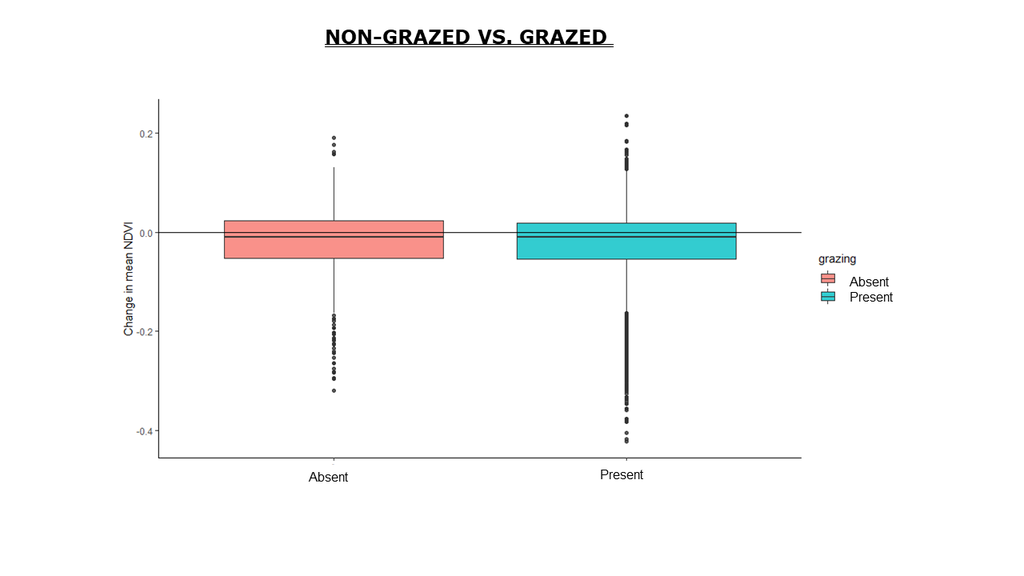

```python
R --vanilla -q

grazed_areas <- read.csv("/SU/course/Geocomputation/LVM_shared/grazed.csv")

grazed_areas <-grazed_areas %>% select(-c(REGANSV,REGDAT,OBJECTID,SHAPE_AREA, SHAPE_LEN, AREAL, PROCENT3,PROCENT2,PROCENT1,URL,LnKod,LnNamn, NATURTYP,X_mean,X_stdev, grazedcount,grazedsum ))%>%
  rename(grazing=mean)

grazed_areas [is.na(grazed_areas)] <- 0

grazed_areas$grazing <- as.factor(grazed_areas$grazing)


combined_v1 <- full_join (combined, grazed_areas, by ="ID")

ndvi_shift<-combined_v1 %>%mutate(ndvi_change = mean_second -mean_first)

ggplot(ndvi_shift, aes(x = grazing, y = ndvi_change, fill=grazing))+
  geom_boxplot(size=0.5, alpha=0.8)+
  labs(x= "Grassland type", y="Change in mean NDVI") +
  geom_hline(yintercept = 0)+
  theme_classic()
```

To improve the process and get a more reliable results with less outliers. It would be a good idea to look surface cover in more details (Due to NDVI could be affected by the condition of the surface.)For instance, could add the rockiness of the surface from soil data or forest/shrub cover of the pasture and meadows. However, another alternative is to focus on grasslands which has been visted and have available data about grazing intesity, surface cover, soil etc.

```python
!jupyter nbconvert rozalia_project.ipynb --to html
```